# mohammed

### Test for Mohammed

This container was started with

**sudo docker run -d -p 433:8888 --name=sar -v /home/mort/imagery/mohammed/Data:/home/imagery mort/sardocker**

```python
%matplotlib inline
```

Here are the RadarSat-2 quadpol coherency matrix image directories as created from the Sentinel-1 Toolbox:

```python
ls /home/imagery
```

```
RS2_OK82571_PK721079_DK650144_FQ17W_20160403_230258_HH_VV_HV_VH_SLC/
RS2_OK82571_PK721080_DK650145_FQ17W_20160427_230257_HH_VV_HV_VH_SLC/
RS2_OK82571_PK721081_DK650146_FQ17W_20160614_230256_HH_VV_HV_VH_SLC/
mohammed.ipynb
```

To combine the matrix bands into a single GeoTiff image, we run the python script ingestrs2quad.py:

```python
run /home/ingestrs2quad /home/imagery/RS2_OK82571_PK721079_DK650144_FQ17W_20160403_230258_HH_VV_HV_VH_SLC/
```

```
Overwriting previous combined image
=========================
     Ingest SAR
=========================
Mon Dec  5 19:55:36 2016
Directory /home/imagery/RS2_OK82571_PK721079_DK650144_FQ17W_20160403_230258_HH_VV_HV_VH_SLC/
writing band 1
writing band 2
writing band 3
writing band 4
writing band 5
writing band 6
writing band 7
writing band 8
writing band 9
elapsed time: 0.096718788147
Multiband image is /home/imagery/RS2_OK82571_PK721079_DK650144_FQ17W_20160403_230258_HH_VV_HV_VH_SLC/polSAR.tif
```

```python
run /home/ingestrs2quad /home/imagery/RS2_OK82571_PK721080_DK650145_FQ17W_20160427_230257_HH_VV_HV_VH_SLC/
```

```
Overwriting previous combined image
=========================
     Ingest SAR
=========================
Mon Dec  5 19:55:40 2016
Directory /home/imagery/RS2_OK82571_PK721080_DK650145_FQ17W_20160427_230257_HH_VV_HV_VH_SLC/
writing band 1
writing band 2
writing band 3
writing band 4
writing band 5
writing band 6
writing band 7
writing band 8
writing band 9
elapsed time: 0.102590799332
Multiband image is /home/imagery/RS2_OK82571_PK721080_DK650145_FQ17W_20160427_230257_HH_VV_HV_VH_SLC/polSAR.tif
```

```python
run /home/ingestrs2quad /home/imagery/RS2_OK82571_PK721081_DK650146_FQ17W_20160614_230256_HH_VV_HV_VH_SLC/
```

```
=========================
     Ingest SAR
=========================
Mon Dec  5 19:55:45 2016
Directory /home/imagery/RS2_OK82571_PK721081_DK650146_FQ17W_20160614_230256_HH_VV_HV_VH_SLC/
writing band 1
writing band 2
writing band 3
writing band 4
writing band 5
writing band 6
writing band 7
writing band 8
writing band 9
elapsed time: 0.0980389118195
Multiband image is /home/imagery/RS2_OK82571_PK721081_DK650146_FQ17W_20160614_230256_HH_VV_HV_VH_SLC/polSAR.tif
```

Here is an RGB display of the three diagonal matrix elements of the above image (bands 1,6 and 9):

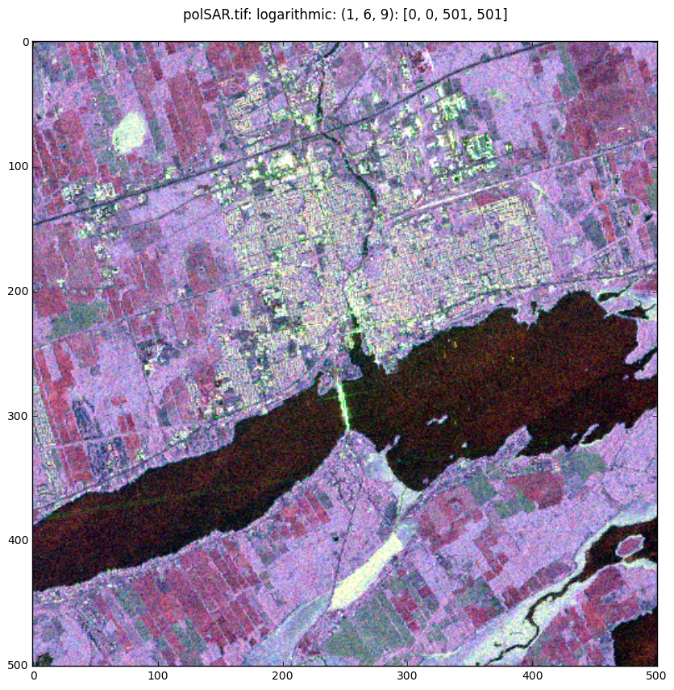

```python
run /home/dispms -f /home/imagery/RS2_OK82571_PK721081_DK650146_FQ17W_20160614_230256_HH_VV_HV_VH_SLC/polSAR.tif \
-p [1,6,9]
```

To estimate the equivalent number of looks, run the python script enlml.py:

```
=========================
     ENL Estimation
=========================
Mon Dec  5 20:13:38 2016
infile:  /home/imagery/RS2_OK82571_PK721081_DK650146_FQ17W_20160614_230256_HH_VV_HV_VH_SLC/polSAR.tif
Quad polarimetry
filtering...
row:  100  200  300  400
```

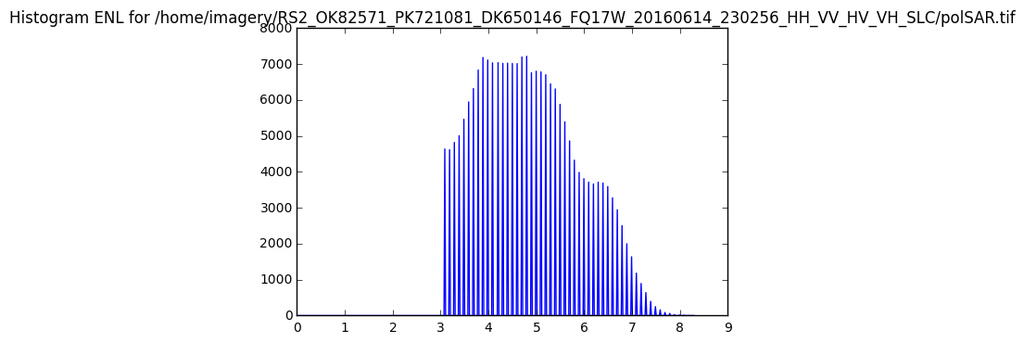

```
 ENL image written to: /home/imagery/RS2_OK82571_PK721081_DK650146_FQ17W_20160614_230256_HH_VV_HV_VH_SLC/polSAR_enl.tif
elapsed time: 31.0030419827
```

```python
run /home/enlml /home/imagery/RS2_OK82571_PK721081_DK650146_FQ17W_20160614_230256_HH_VV_HV_VH_SLC/polSAR.tif
```

So the ENL would appear to be about 5.

To run the change sequential change detection on the three images, run the bash script sar_seq_rs2quad.sh. It gathers the three images together and calls the python script sar_seq.py which does the change detection. By choosing a spatial subset (in this case 400x400), the images are clipped and co-registered to the first image. This might be unnecessary if the images are well registered anyway.

If you have a multicore processor you can eneable parallel computation by openeing a terminal window in the container (new terminal) and running

ipcluster start -n 4

```python
!/home/sar_seq_rs2quad.sh 20160403 20160427 20160614 [50,50,400,400] 5 0.01
```

```
***** Multitemporal PolSAR Change Detection **********
***** Radarsat2 quadpol imagery **********************
***** Pre-processed with Sentinel-1 Toolbox **********
number of images    3
ENL                 5
spatial subset      [50,50,400,400]
significance level  0.01
===========================
Spatial/spectral subsetting
===========================
Mon Dec  5 20:19:24 2016
Input /home/imagery/RS2_OK82571_PK721079_DK650144_FQ17W_20160403_230258_HH_VV_HV_VH_SLC/polSAR.tif
elapsed time: 0.104513168335

attempting parallel execution of co-registration ...
available engines [0, 1, 2, 3]
elapsed time for co-registration: 1.67117404938
===============================================
     Multi-temporal SAR Change Detection
===============================================
Mon Dec  5 20:19:26 2016
First (reference) filename:  /home/imagery/RS2_OK82571_PK721079_DK650144_FQ17W_20160403_230258_HH_VV_HV_VH_SLC/polSAR_sub.tif
number of images: 3
equivalent number of looks: 5.000000
significance level: 0.010000
pre-calculating Rj and p-values ...
attempting parallel calculation ...
available engines [0, 1, 2, 3]
ell =  1 2
elapsed time for p-value calculation: 0.960603952408
most recent change map written to: /home/imagery/RS2_OK82571_PK721079_DK650144_FQ17W_20160403_230258_HH_VV_HV_VH_SLC/sarseq(20160403-1-20160614)_cmap.tif
frequency map written to: /home/imagery/RS2_OK82571_PK721079_DK650144_FQ17W_20160403_230258_HH_VV_HV_VH_SLC/sarseq(20160403-1-20160614)_fmap.tif
bitemporal map image written to: /home/imagery/RS2_OK82571_PK721079_DK650144_FQ17W_20160403_230258_HH_VV_HV_VH_SLC/sarseq(20160403-1-20160614)_bmap.tif
first change map written to: /home/imagery/RS2_OK82571_PK721079_DK650144_FQ17W_20160403_230258_HH_VV_HV_VH_SLC/sarseq(20160403-1-20160614)_smap.tif
total elapsed time: 2.75812101364
```

Here is the change map for the most recent changes:

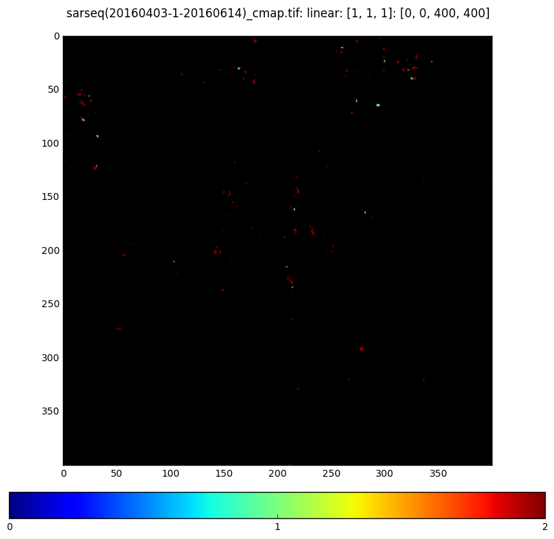

```python
run /home/dispms \
-f /home/imagery/RS2_OK82571_PK721079_DK650144_FQ17W_20160403_230258_HH_VV_HV_VH_SLC/sarseq(20160403-1-20160614)_cmap.tif -c
```